```r
library(worldfootballR)
library(tidyverse)
library(ggsoccer)
```

In the first section, I’ll perform EDA on the scraped data from the worldfootballR_data repo. I’ll start by loading match results for the top 5 European leagues for the past decade.  
Then, I’ll briefly view the data and check if there’s any gaps in important variables.

```r
topleagues_data <- load_match_results(country = c("ENG", "ESP", "GER", "ITA", "FRA"), gender = c("M"), season_end_year = c(2015:2025), tier = "1st")
```

```
## → Data last updated 2025-02-04 17:32:08.29795408248901 UTC
```

```r
nrow(topleagues_data)
```

```
## [1] 19969
```

```r
glimpse(topleagues_data)
```

```
## Rows: 19,969
## Columns: 20
## $ Competition_Name <chr> "Premier League", "Premier League", "Premier League", "Premier League", "Premier League", "Premier L…
## $ Gender           <chr> "M", "M", "M", "M", "M", "M", "M", "M", "M", "M", "M", "M", "M", "M", "M", "M", "M", "M", "M", "M", …
## $ Country          <chr> "ENG", "ENG", "ENG", "ENG", "ENG", "ENG", "ENG", "ENG", "ENG", "ENG", "ENG", "ENG", "ENG", "ENG", "E…
## $ Season_End_Year  <int> 2015, 2015, 2015, 2015, 2015, 2015, 2015, 2015, 2015, 2015, 2015, 2015, 2015, 2015, 2015, 2015, 2015…
## $ Round            <chr> NA, NA, NA, NA, NA, NA, NA, NA, NA, NA, NA, NA, NA, NA, NA, NA, NA, NA, NA, NA, NA, NA, NA, NA, NA, …
## $ Wk               <chr> "1", "1", "1", "1", "1", "1", "1", "1", "1", "1", "2", "2", "2", "2", "2", "2", "2", "2", "2", "2", …
## $ Day              <chr> "Sat", "Sat", "Sat", "Sat", "Sat", "Sat", "Sat", "Sun", "Sun", "Mon", "Sat", "Sat", "Sat", "Sat", "S…
## $ Date             <date> 2014-08-16, 2014-08-16, 2014-08-16, 2014-08-16, 2014-08-16, 2014-08-16, 2014-08-16, 2014-08-17, 201…
## $ Time             <chr> "12:45", "15:00", "15:00", "15:00", "15:00", "15:00", "17:30", "13:30", "16:00", "20:00", "12:45", "…
## $ Home             <chr> "Manchester Utd", "Stoke City", "Leicester City", "QPR", "West Ham", "West Brom", "Arsenal", "Liverp…
## $ HomeGoals        <dbl> 1, 0, 2, 0, 0, 2, 2, 2, 0, 1, 0, 1, 1, 2, 0, 2, 4, 1, 1, 3, 0, 1, 0, 1, 3, 3, 3, 0, 2, 1, 2, 0, 0, 4…
## $ Home_xG          <dbl> NA, NA, NA, NA, NA, NA, NA, NA, NA, NA, NA, NA, NA, NA, NA, NA, NA, NA, NA, NA, NA, NA, NA, NA, NA, …
## $ Away             <chr> "Swansea City", "Aston Villa", "Everton", "Hull City", "Tottenham", "Sunderland", "Crystal Palace", …
## $ AwayGoals        <dbl> 2, 1, 2, 1, 1, 2, 1, 1, 2, 3, 0, 0, 3, 0, 0, 2, 0, 1, 1, 1, 0, 0, 1, 3, 0, 3, 6, 3, 1, 1, 2, 1, 2, 0…
## $ Away_xG          <dbl> NA, NA, NA, NA, NA, NA, NA, NA, NA, NA, NA, NA, NA, NA, NA, NA, NA, NA, NA, NA, NA, NA, NA, NA, NA, …
## $ Attendance       <dbl> 75339, 27478, 31603, 17603, 34977, 25468, 59962, 44736, 50816, 20699, 30267, 20565, 24242, 41604, 27…
## $ Venue            <chr> "Old Trafford", "Bet365 Stadium", "King Power Stadium", "Loftus Road Stadium", "Boleyn Ground", "The…
## $ Referee          <chr> "Mike Dean", "Anthony Taylor", "Mike Dean", "Craig Pawson", "Chris Foy", "Niel Swarbrick", "Jonathan…
## $ Notes            <chr> NA, NA, NA, NA, NA, NA, NA, NA, NA, NA, NA, NA, NA, NA, NA, NA, NA, NA, NA, NA, NA, NA, NA, NA, NA, …
## $ MatchURL         <chr> "https://fbref.com/en/matches/d192bd78/Manchester-United-Swansea-City-August-16-2014-Premier-League"…
```

```r
summary(topleagues_data[, c("Home_xG", "Away_xG", "HomeGoals", "AwayGoals")])
```

```
##     Home_xG         Away_xG        HomeGoals        AwayGoals
##  Min.   :0.000   Min.   :0.000   Min.   : 0.000   Min.   :0.000
##  1st Qu.:0.900   1st Qu.:0.700   1st Qu.: 1.000   1st Qu.:0.000
##  Median :1.400   Median :1.100   Median : 1.000   Median :1.000
##  Mean   :1.497   Mean   :1.215   Mean   : 1.542   Mean   :1.228
##  3rd Qu.:2.000   3rd Qu.:1.600   3rd Qu.: 2.000   3rd Qu.:2.000
##  Max.   :7.000   Max.   :5.600   Max.   :10.000   Max.   :9.000
##  NA's   :6316    NA's   :6316    NA's   :806      NA's   :806
```

There’s a lot of NA values, especially for xG. I’ll use the naniar package to visually inspect where these values are.

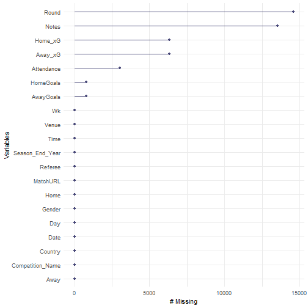

```r
library(naniar)
gg_miss_var(topleagues_data)
```

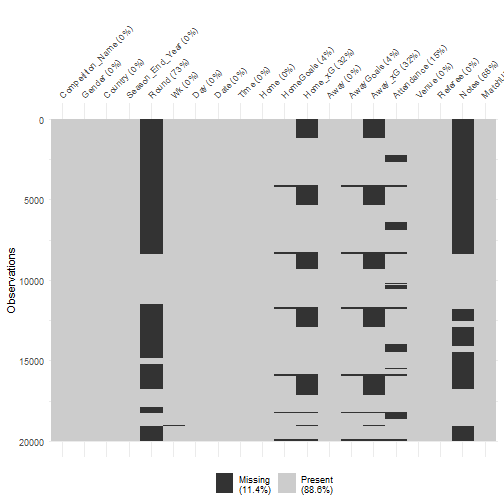

```r
vis_miss(topleagues_data)
```

A lot of NA values for Round is plausible (these are usually reserved for cup competitions).  
It’s important to note the missing Attendance values, however.  
It appears the xG values that are missing originate at the beginning of the data for each league. There are five blocks of missing xG data which corresponds to the five leagues I’ve imported.  
These blocks appear to be at the start of the data, which could mean xG data is only availabe past a certain year.  
I’ll import a new dataset starting from a later year and run the same test to double-check.

```r
recent_topleagues_data <- load_match_results(country = c("ENG", "ESP", "GER", "ITA", "FRA"), gender = c("M"), season_end_year = c(2018:2025), tier = "1st")
```

```
## → Data last updated 2025-02-04 17:32:08.29795408248901 UTC
```

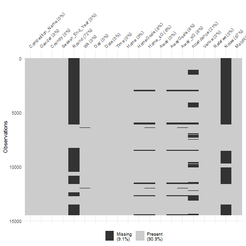

```r
vis_miss(recent_topleagues_data)
```

It’s clear that the missing data values for xG corresponded to my timeframe of data, as changing my start date from 2015 to 2018 reduced the missing values from 32% to 6%.  
However, there are still some values missing, and I think this is because the data was last updated in February 2025 while the current 2025 season ends in May.  
The fixtures up until May 2025 are confirmed, that’s why they are in the dataset. The only things missing in theory should be the xG.  
This is because xG is recorded as the match is played, while all of the other data is determined and fixed ahead of the 24/25 season. To confirm this hypothesis, I’ll extract all data before this date and confirm no data is missing. In order to do this, the values in the Date column must be of data type Date, which I’ll confirm now.

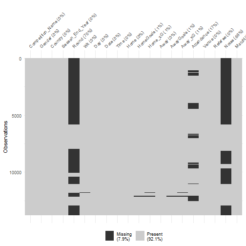

```r
topleagues_data <- topleagues_data %>%
  mutate(Date = as.Date(Date))
recent_topleagues_before_February <- recent_topleagues_data %>%
  filter(Date < as.Date("2025-02-04"))
vis_miss(recent_topleagues_before_February)
```

Only 1% of the xG data remains missing. I’ll make a new dataframe with just those rows and inspect it to see where the missing data is.

```r
missing_xg_rows <- recent_topleagues_before_February %>%
  filter(is.na(Home_xG) | is.na(Away_xG))
missing_xg_rows %>%
  select(Date, Competition_Name, Home, Away, Home_xG, Away_xG)
```

```
##           Date   Competition_Name          Home          Away Home_xG Away_xG
## 1   2018-05-17 Fußball-Bundesliga     Wolfsburg Holstein Kiel      NA      NA
## 2   2018-05-21 Fußball-Bundesliga Holstein Kiel     Wolfsburg      NA      NA
## 3   2019-05-23 Fußball-Bundesliga     Stuttgart  Union Berlin      NA      NA
## 4   2019-05-27 Fußball-Bundesliga  Union Berlin     Stuttgart      NA      NA
## 5   2020-07-02 Fußball-Bundesliga Werder Bremen    Heidenheim      NA      NA
## 6   2020-07-06 Fußball-Bundesliga    Heidenheim Werder Bremen      NA      NA
## 7   2021-05-26 Fußball-Bundesliga          Köln Holstein Kiel      NA      NA
## 8   2021-05-29 Fußball-Bundesliga Holstein Kiel          Köln      NA      NA
## 9   2022-03-18 Fußball-Bundesliga        Bochum    M'Gladbach      NA      NA
## 10  2022-05-19 Fußball-Bundesliga    Hertha BSC  Hamburger SV      NA      NA
## 11  2022-05-23 Fußball-Bundesliga  Hamburger SV    Hertha BSC      NA      NA
## 12  2023-06-01 Fußball-Bundesliga     Stuttgart  Hamburger SV      NA      NA
## 13  2023-06-05 Fußball-Bundesliga  Hamburger SV     Stuttgart      NA      NA
## 14  2024-05-23 Fußball-Bundesliga        Bochum    Düsseldorf      NA      NA
```

[output cut: 111 more lines]

```r
glimpse(missing_xg_rows)
```

```
## Rows: 125
## Columns: 20
## $ Competition_Name <chr> "Fußball-Bundesliga", "Fußball-Bundesliga", "Fußball-Bundesliga", "Fußball-Bundesliga", "Fußball-Bun…
## $ Gender           <chr> "M", "M", "M", "M", "M", "M", "M", "M", "M", "M", "M", "M", "M", "M", "M", "M", "M", "M", "M", "M", …
## $ Country          <chr> "GER", "GER", "GER", "GER", "GER", "GER", "GER", "GER", "GER", "GER", "GER", "GER", "GER", "GER", "G…
## $ Season_End_Year  <int> 2018, 2018, 2019, 2019, 2020, 2020, 2021, 2021, 2022, 2022, 2022, 2023, 2023, 2024, 2024, 2021, 2018…
## $ Round            <chr> "German 1/2 Relegation/Promotion Playoffs", "German 1/2 Relegation/Promotion Playoffs", "German 1/2 …
## $ Wk               <chr> NA, NA, NA, NA, NA, NA, NA, NA, "27", NA, NA, NA, NA, NA, NA, "1", NA, NA, NA, NA, "29", "29", "29",…
## $ Day              <chr> "Thu", "Mon", "Thu", "Mon", "Thu", "Mon", "Wed", "Sat", "Fri", "Thu", "Mon", "Thu", "Mon", "Thu", "M…
## $ Date             <date> 2018-05-17, 2018-05-21, 2019-05-23, 2019-05-27, 2020-07-02, 2020-07-06, 2021-05-26, 2021-05-29, 202…
## $ Time             <chr> "20:30", "20:30", "20:30", "20:30", "20:30", "20:30", "18:30", "18:00", "20:30", "20:30", "20:30", "…
## $ Home             <chr> "Wolfsburg", "Holstein Kiel", "Stuttgart", "Union Berlin", "Werder Bremen", "Heidenheim", "Köln", "H…
## $ HomeGoals        <dbl> 3, 0, 2, 0, 0, 2, 0, 1, 0, 0, 0, 3, 1, 0, 0, 3, 0, 1, 1, 3, NA, NA, NA, NA, NA, NA, NA, NA, NA, NA, …
## $ Home_xG          <dbl> NA, NA, NA, NA, NA, NA, NA, NA, NA, NA, NA, NA, NA, NA, NA, NA, NA, NA, NA, NA, NA, NA, NA, NA, NA, …
## $ Away             <chr> "Holstein Kiel", "Wolfsburg", "Union Berlin", "Stuttgart", "Heidenheim", "Werder Bremen", "Holstein …
## $ AwayGoals        <dbl> 1, 1, 2, 0, 0, 2, 1, 5, 2, 1, 2, 0, 3, 3, 0, 0, 3, 0, 1, 1, NA, NA, NA, NA, NA, NA, NA, NA, NA, NA, …
## $ Away_xG          <dbl> NA, NA, NA, NA, NA, NA, NA, NA, NA, NA, NA, NA, NA, NA, NA, NA, NA, NA, NA, NA, NA, NA, NA, NA, NA, …
## $ Attendance       <dbl> 28800, 12000, 58619, 22012, NA, NA, NA, NA, NA, 75500, 57000, 48500, 55500, 26000, 51500, NA, NA, 25…
## $ Venue            <chr> "Volkswagen Arena", "Holstein-Stadion", "Mercedes-Benz Arena", "Stadion An der Alten Försterei", "We…
## $ Referee          <chr> "", "", "", "", "", "", "", "", "Benjamin Cortus", "", "", "", "", "", "", "Daniele Chiffi", "", "",…
## $ Notes            <chr> "Leg 1 of 2", "Leg 2 of 2; Wolfsburg won", "Leg 1 of 2", "Leg 2 of 2; Union Berlin won", "Leg 1 of 2…
## $ MatchURL         <chr> "https://fbref.com/en/matches/5dc40876/Wolfsburg-Holstein-Kiel-May-17-2018-German-12-RelegationPromo…
```

There’s only 125 rows, which means the select() function showed the whole dataframe.  
The Ligue 1 (French league) 2019/20 season was suspended on March 13 2020 due to the coronavirus and cancelled on April 20, therefore those matches were never actually played. This explains why there is no xG data for Ligue 1 during this timeframe.  
The remaining missing Ligue 1 and Bundesliga data (except for one game) is because those games were the relegation play-offs of those leagues. These two leagues are the only top 5 leagues that adopt a system of relegation play-offs. This is a system whereby 16th place in the league (third from bottom) plays 3rd place from the second tier in two games: one home and one away. The winner, decided by aggregate score, either remains or is promoted to the first divison for next season. The loser remains/is relegated to the second division. It’s arguable as to whether these games count towards the league. Since they don’t comprise of the 38 (or 34) games each team plays in a standard league season, I won’t count them. It feels unfair to take stats for some teams playing 34 games and others playing 36.  
There’s one Bundesliga game that wasn’t a playoff, however, which was the Bochum vs M’Gladbach match on 2022-03-18. It’s clear this isn’t a playoff game because there was no return game between Gladbach and Bochum (all of the playoffs are in pairs). This game also took place mid-season while the other games took place between May and July (att he end of the season). In this game, Gladbach led 2-0 at around the 68-70th minute when assistant referee Christian Gittelmann was struck in the head by a beer cup thrown from the crowd at Bochum’s stadium. This resulted in a serious injury and referee Benjamin Cortus abandoned the match shortly after for security reasons. The German Football Association awarded the game as a Gladbach 2-0 win as opposed to a replay. Bochum’s appeal for a replay was later withdrew.  
The final outlier is the September 2020 game between Hellas Verona and Roma in Italy’s Serie A. The game ended 0-0 in regulation time, however Verona was awarded a 3-0 forfeit win by the Italian Football Federation afterwards. This is because Roma fielded an ineligible player (Amadou Diawara) who had just turned 23 but was registered in the under-22 registration list. It was a small mistake, but it gave Verona the win. This is probably the reason why the xG and goal count wasn’t collected in the dataset.  
In conclusion, there are two outliers to look out for when analysing Bundesliga and Serie A data, and Ligue 1 data analysis for the 2019/20 season will be skewed because of its cancellation.  
Now, I’ll do the same tests on data from the most prominent football cup competitions worldwide (domestic and international). I’ll also take a quick look at them and check for missing data.

```r
cups <- c("Africa Cup of Nations", "CONMEBOL Copa América", "Copa del Rey", "Coppa Italia", "Coupe de France", " DFB-Pokal", "EFL Cup", "FA Cup", "FIFA World Cup", "UEFA Champions League", "UEFA Conference League", "UEFA Europa League", "UEFA European Football Championship")
cups_data <- load_match_comp_results(comp_name = cups)
```

```
## → Data last updated 2024-02-15 17:17:59.4536941051483 UTC
```

```r
glimpse(cups_data)
```

```
## Rows: 20,003
## Columns: 20
## $ Competition_Name <chr> "Africa Cup of Nations", "Africa Cup of Nations", "Africa Cup of Nations", "Africa Cup of Nations", …
## $ Gender           <chr> "M", "M", "M", "M", "M", "M", "M", "M", "M", "M", "M", "M", "M", "M", "M", "M", "M", "M", "M", "M", …
## $ Country          <chr> NA, NA, NA, NA, NA, NA, NA, NA, NA, NA, NA, NA, NA, NA, NA, NA, NA, NA, NA, NA, NA, NA, NA, NA, NA, …
## $ Season_End_Year  <int> 2010, 2010, 2010, 2010, 2010, 2010, 2010, 2010, 2010, 2010, 2010, 2010, 2010, 2010, 2010, 2010, 2010…
## $ Round            <chr> "Group stage", "Group stage", "Group stage", "Group stage", "Group stage", "Group stage", "Group sta…
## $ Wk               <chr> "1", "1", "1", "1", "1", "1", "1", "1", "2", "2", "2", "2", "2", "2", "2", "2", "3", "3", "3", "3", …
## $ Day              <chr> "Sun", "Mon", "Mon", "Mon", "Tue", "Tue", "Wed", "Wed", "Thu", "Thu", "Fri", "Fri", "Sat", "Sat", "S…
## $ Date             <date> 2010-01-10, 2010-01-11, 2010-01-11, 2010-01-11, 2010-01-12, 2010-01-12, 2010-01-13, 2010-01-13, 201…
## $ Time             <chr> "20:00", "14:45", "17:00", "19:30", "17:00", "19:30", "17:00", "19:30", "17:00", "19:30", "17:00", "…
## $ Home             <chr> "Angola ao", "Malawi mw", "Côte d'Ivoire ci", "Ghana gh", "Egypt eg", "Mozambique mz", "Cameroon cm"…
## $ HomeGoals        <dbl> 4, 3, 0, NA, 3, 2, 0, 1, 0, 2, NA, 3, 1, 2, 0, 3, 0, 3, NA, 0, 3, 2, 2, 1, 0, 2, 3, 0, 1, 0, 1, 0, 1…
## $ Away             <chr> "ml Mali", "dz Algeria", "bf Burkina Faso", "tg Togo", "ng Nigeria", "bj Benin", "ga Gabon", "tn Tun…
## $ AwayGoals        <dbl> 4, 0, 0, NA, 1, 2, 1, 1, 1, 0, NA, 1, 0, 0, 0, 2, 0, 1, NA, 1, 0, 0, 2, 2, 1, 3, 1, 0, 0, 4, 0, 1, 0…
## $ Attendance       <dbl> 48000, 1000, 5000, NA, 18000, 15000, 15000, 17000, 4000, 48500, NA, 23000, 8000, 16000, 16000, 15000…
## $ Venue            <chr> "Estádio 11 de Novembro", "Estádio 11 de Novembro", "Estádio Nacional do Chiazi", "Estádio Nacional …
## $ Referee          <chr> "Essam Abd El Fatah", "Badara Diatta", "Kacem Bennaceur", "", "Rajindraparsad Seechurn", "Khalid Abd…
## $ Notes            <chr> "", "", "", "Match Cancelled", "", "", "", "", "", "", "Match Cancelled", "", "", "", "", "", "", ""…
## $ MatchURL         <chr> "https://fbref.com/en/matches/4cca8840/Angola-Mali-January-10-2010-Africa-Cup-of-Nations", "https://…
## $ Home_xG          <dbl> NA, NA, NA, NA, NA, NA, NA, NA, NA, NA, NA, NA, NA, NA, NA, NA, NA, NA, NA, NA, NA, NA, NA, NA, NA, …
## $ Away_xG          <dbl> NA, NA, NA, NA, NA, NA, NA, NA, NA, NA, NA, NA, NA, NA, NA, NA, NA, NA, NA, NA, NA, NA, NA, NA, NA, …
```

There’s a lot of data here, though the most important is xG. I’ll perform the same visual inspection of missing values.

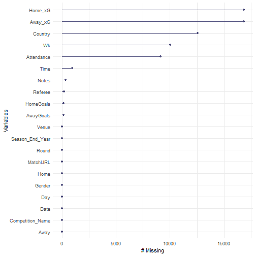

```r
gg_miss_var(cups_data)
```

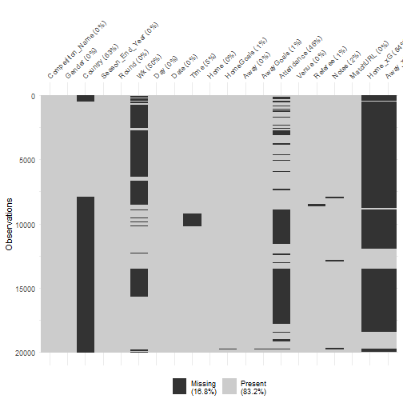

```r
vis_miss(cups_data)
```

There’s quite a lot of missing xG data. I’ll first filter out all data before the 2017/18 season, as this is when xG collection began. I’ll do the same step of converting the Date column values to have the Date data type.  
The other missing valuesw like Week and Attendance don’t matter as much (Week can be pulled from the Date) and attendance isn’t necessary for player/team analysis.

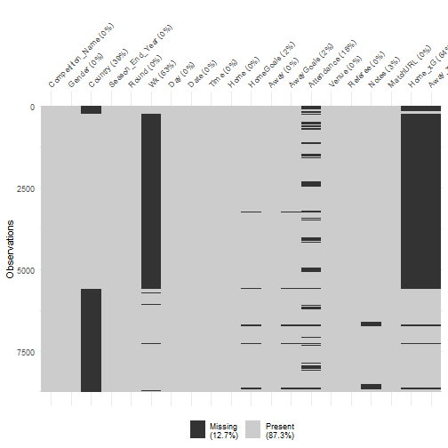

```r
cups_data <- cups_data %>%
  mutate(Date = as.Date(Date))
filtered_cups_data <- filter(cups_data, Date > as.Date("2017-06-06"))
vis_miss(filtered_cups_data)
```

It’s better, going from 84% missing to 64% missing, though there’s still a lot of missing data. I’ll filter out the rows with missing xG and look at them now.

```r
missing_cup_xg_rows <- filtered_cups_data %>%
  filter(is.na(Home_xG) | is.na(Away_xG))
missing_cup_xg_rows %>%
  select(Date, Competition_Name, Home, Away, Home_xG, Away_xG)
```

```
##           Date      Competition_Name             Home             Away Home_xG Away_xG
## 1   2019-06-21 Africa Cup of Nations         Egypt eg      zw Zimbabwe      NA      NA
## 2   2019-06-22 Africa Cup of Nations      Congo DR cd        ug Uganda      NA      NA
## 3   2019-06-22 Africa Cup of Nations       Nigeria ng       bi Burundi      NA      NA
## 4   2019-06-22 Africa Cup of Nations        Guinea gn    mg Madagascar      NA      NA
## 5   2019-06-23 Africa Cup of Nations       Morocco ma       na Namibia      NA      NA
## 6   2019-06-23 Africa Cup of Nations       Senegal sn      tz Tanzania      NA      NA
## 7   2019-06-23 Africa Cup of Nations       Algeria dz         ke Kenya      NA      NA
## 8   2019-06-24 Africa Cup of Nations Côte d'Ivoire ci  za South Africa      NA      NA
## 9   2019-06-24 Africa Cup of Nations       Tunisia tn        ao Angola      NA      NA
## 10  2019-06-24 Africa Cup of Nations          Mali ml    mr Mauritania      NA      NA
## 11  2019-06-25 Africa Cup of Nations      Cameroon cm gw Guinea-Bissau      NA      NA
## 12  2019-06-25 Africa Cup of Nations         Ghana gh         bj Benin      NA      NA
## 13  2019-06-26 Africa Cup of Nations       Nigeria ng        gn Guinea      NA      NA
## 14  2019-06-26 Africa Cup of Nations        Uganda ug      zw Zimbabwe      NA      NA
```

[output cut: 153 more lines]

```r
glimpse(missing_cup_xg_rows)
```

```
## Rows: 5,588
## Columns: 20
## $ Competition_Name <chr> "Africa Cup of Nations", "Africa Cup of Nations", "Africa Cup of Nations", "Africa Cup of Nations", …
## $ Gender           <chr> "M", "M", "M", "M", "M", "M", "M", "M", "M", "M", "M", "M", "M", "M", "M", "M", "M", "M", "M", "M", …
## $ Country          <chr> NA, NA, NA, NA, NA, NA, NA, NA, NA, NA, NA, NA, NA, NA, NA, NA, NA, NA, NA, NA, NA, NA, NA, NA, NA, …
## $ Season_End_Year  <int> 2019, 2019, 2019, 2019, 2019, 2019, 2019, 2019, 2019, 2019, 2019, 2019, 2019, 2019, 2019, 2019, 2019…
## $ Round            <chr> "Group stage", "Group stage", "Group stage", "Group stage", "Group stage", "Group stage", "Group sta…
## $ Wk               <chr> "1", "1", "1", "1", "1", "1", "1", "1", "1", "1", "1", "1", "2", "2", "2", "2", "2", "2", "2", "2", …
## $ Day              <chr> "Fri", "Sat", "Sat", "Sat", "Sun", "Sun", "Sun", "Mon", "Mon", "Mon", "Tue", "Tue", "Wed", "Wed", "W…
## $ Date             <date> 2019-06-21, 2019-06-22, 2019-06-22, 2019-06-22, 2019-06-23, 2019-06-23, 2019-06-23, 2019-06-24, 201…
## $ Time             <chr> "22:00", "16:30", "19:00", "22:00", "16:30", "19:00", "22:00", "16:30", "19:00", "22:00", "19:00", "…
## $ Home             <chr> "Egypt eg", "Congo DR cd", "Nigeria ng", "Guinea gn", "Morocco ma", "Senegal sn", "Algeria dz", "Côt…
## $ HomeGoals        <dbl> 1, 0, 1, 2, 1, 2, 2, 1, 1, 4, 2, 2, 1, 1, 2, 1, 0, 3, 1, 1, 1, 0, 0, 0, 2, 0, 0, 0, 0, 1, 0, 0, 0, 0…
## $ Away             <chr> "zw Zimbabwe", "ug Uganda", "bi Burundi", "mg Madagascar", "na Namibia", "tz Tanzania", "ke Kenya", …
## $ AwayGoals        <dbl> 0, 2, 0, 2, 0, 0, 0, 0, 1, 1, 0, 2, 0, 1, 0, 0, 1, 2, 1, 0, 0, 0, 0, 0, 0, 2, 2, 4, 1, 4, 3, 3, 2, 0…
## $ Attendance       <dbl> NA, NA, NA, NA, NA, NA, NA, NA, NA, NA, NA, NA, NA, NA, NA, NA, NA, NA, NA, NA, NA, NA, NA, NA, NA, …
## $ Venue            <chr> "Cairo International Stadium (Neutral Site)", "Cairo International Stadium (Neutral Site)", "Alexand…
## $ Referee          <chr> "Alioum Alioum", "Rédouane Jiyed", "Bernard Camille", "Amin Omar", "Louis Hakizimana", "Sadok Selmi"…
## $ Notes            <chr> "", "", "", "", "", "", "", "", "", "", "", "", "", "", "", "", "", "", "", "", "", "", "", "", "", …
## $ MatchURL         <chr> "https://fbref.com/en/matches/7c214290/Egypt-Zimbabwe-June-21-2019-Africa-Cup-of-Nations", "https://…
## $ Home_xG          <dbl> NA, NA, NA, NA, NA, NA, NA, NA, NA, NA, NA, NA, NA, NA, NA, NA, NA, NA, NA, NA, NA, NA, NA, NA, NA, …
## $ Away_xG          <dbl> NA, NA, NA, NA, NA, NA, NA, NA, NA, NA, NA, NA, NA, NA, NA, NA, NA, NA, NA, NA, NA, NA, NA, NA, NA, …
```

```r
View(missing_cup_xg_rows)
```

The dataset seems to be lacking quite a lot of data for the domestic cup competitions. Not only was it last updated in February 2024 (no data for the 24/25 season), very little xG data from 2018-2024 for the domestic cup competitions exists. Simply because there is so much missing data I don’t think this data is usable for my analysis, I’ll most likely be using the UnderStat data (which I’ll analyse in a later section) as there’s simply too much missing here.  
The main problem is there’s data missing which simply shouldn’t be. For example, there should be xG data for the 2020 FA Cup tie between Tottenham and Norwhich (I can access it easily online) but it’s just not there.  
There’s many other databases I can pull data from with this package, so I’ll use cup data from one of them.